# M5 Dataset: Exploratory Data Analysis (EDA)

> In this notebook, we explore and prepare the official Walmart M5 Forecasting Accuracy dataset for downstream modeling and anomaly detection. We'll examine the structure, understand data sources, and visualize patterns to guide feature engineering and forecasting design.

**Dataset Source**: [M5 Forecasting - Accuracy (Kaggle)](https://www.kaggle.com/competitions/m5-forecasting-accuracy/data)

**Use Case**: Build store-item-level forecasting and anomaly detection system for Walmart’s retail demand planning.

## Step 1: Import Libraries

We'll use common data science packages for analysis, visualization, and path management.

```python
import pandas as pd
import numpy as np
import matplotlib.pyplot as plt
import seaborn as sns
import os
```

## Step 2: Load M5 Dataset

We load three files:

- `sales_train_validation.csv`: Daily sales by item and store
- `calendar.csv`: Maps day indices to real dates, holidays, and SNAP events
- `sell_prices.csv`: Item prices across stores and weeks

```python
# Adjusted for correct relative path
data_dir = "../data"

sales = pd.read_csv(os.path.join(data_dir, "sales_train_validation.csv"))
calendar = pd.read_csv(os.path.join(data_dir, "calendar.csv"))
prices = pd.read_csv(os.path.join(data_dir, "sell_prices.csv"))

sales.info()
```

```
<class 'pandas.core.frame.DataFrame'>
RangeIndex: 30490 entries, 0 to 30489
Columns: 1919 entries, id to d_1913
dtypes: int64(1913), object(6)
memory usage: 446.4+ MB
```

## Step 3: Dataset Overview – Shapes, Dtypes

We check the basic structure, shape, and memory usage for each dataset to prepare for merging and downstream tasks.

```python
print("Sales shape:", sales.shape)
print("Calendar shape:", calendar.shape)
print("Prices shape:", prices.shape)

print("Sales info: \n", sales.info())
print("Calendar info: \n", calendar.info())
print("Prices info: \n", prices.info())
```

```
Sales shape: (30490, 1919)
Calendar shape: (1969, 14)
Prices shape: (6841121, 4)
<class 'pandas.core.frame.DataFrame'>
RangeIndex: 30490 entries, 0 to 30489
Columns: 1919 entries, id to d_1913
dtypes: int64(1913), object(6)
memory usage: 446.4+ MB
Sales info:
 None
<class 'pandas.core.frame.DataFrame'>
RangeIndex: 1969 entries, 0 to 1968
Data columns (total 14 columns):
 #   Column        Non-Null Count  Dtype
---  ------        --------------  -----
 0   date          1969 non-null   object
 1   wm_yr_wk      1969 non-null   int64
 2   weekday       1969 non-null   object
 3   wday          1969 non-null   int64
 4   month         1969 non-null   int64
 5   year          1969 non-null   int64
 6   d             1969 non-null   object
 7   event_name_1  162 non-null    object
 8   event_type_1  162 non-null    object
 9   event_name_2  5 non-null      object
 10  event_type_2  5 non-null      object
 11  snap_CA       1969 non-null   int64
 12  snap_TX       1969 non-null   int64
 13  snap_WI       1969 non-null   int64
dtypes: int64(7), object(7)
memory usage: 215.5+ KB
Calendar info:
 None
<class 'pandas.core.frame.DataFrame'>
RangeIndex: 6841121 entries, 0 to 6841120
Data columns (total 4 columns):
 #   Column      Dtype
---  ------      -----
 0   store_id    object
 1   item_id     object
 2   wm_yr_wk    int64
 3   sell_price  float64
dtypes: float64(1), int64(1), object(2)
memory usage: 208.8+ MB
Prices info:
 None
```

## Step 4: Null Value Checks

Nulls are expected in some event columns but not in core fields like sales or price. We verify to ensure no data quality issues.

```python
print("Nulls in sales:\n", sales.isnull().sum().sum())
print("Nulls in calendar:\n", calendar.isnull().sum())
print("Nulls in prices:\n", prices.isnull().sum())
```

```
Nulls in sales:
 0
Nulls in calendar:
 date               0
wm_yr_wk           0
weekday            0
wday               0
month              0
year               0
d                  0
event_name_1    1807
event_type_1    1807
event_name_2    1964
event_type_2    1964
snap_CA            0
snap_TX            0
snap_WI            0
dtype: int64
Nulls in prices:
 store_id      0
item_id       0
wm_yr_wk      0
sell_price    0
dtype: int64
```

## Step 5: Sales Distribution & Summary

We inspect the overall distribution of daily item sales to understand scale, sparsity, and outliers.

```
Sales min: 0
Sales max: 763
Sales mean: 1.126322153733316
```

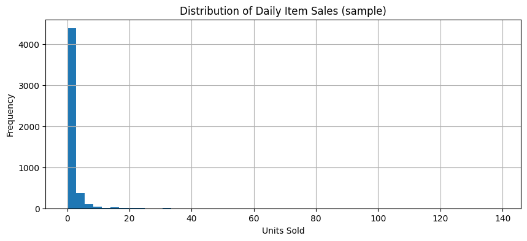

```python
# Sales stats
d_cols = [col for col in sales.columns if col.startswith('d_')]
print("Sales min:", sales[d_cols].min().min())
print("Sales max:", sales[d_cols].max().max())
print("Sales mean:", sales[d_cols].mean().mean())

# Plot histogram
sales[d_cols].stack().astype(int).sample(5000).hist(bins=50, figsize=(10, 4))
plt.title("Distribution of Daily Item Sales (sample)")
plt.xlabel("Units Sold")
plt.ylabel("Frequency")
```

## Step 6: Unique Values in Categorical Columns

We check how many unique items, stores, categories, and departments exist. This informs one-hot encoding, aggregations, and model scaling.

```python
for col in ['item_id', 'dept_id', 'cat_id', 'store_id', 'state_id']:
    print(f"{col}: {sales[col].nunique()} unique values")
```

```
item_id: 3049 unique values
dept_id: 7 unique values
cat_id: 3 unique values
store_id: 10 unique values
state_id: 3 unique values
```

## Step 7: Events and SNAP Days

[figure not shown]

```python
# Events
calendar['event_name_1'].value_counts(dropna=False).plot(kind='bar', figsize=(10,4), title="Event Name Occurrences")

# SNAP flags
calendar[['snap_CA', 'snap_TX', 'snap_WI']].sum().plot(kind='bar', title="SNAP Days per State")
```

## Step 8: Date Range Validation

```python
calendar['date'] = pd.to_datetime(calendar['date'])
print("Date range:", calendar['date'].min(), "to", calendar['date'].max())
```

```
Date range: 2011-01-29 00:00:00 to 2016-06-19 00:00:00
```

## Step 9: Price Trend of Sample Item

We visualize the weekly price of a random item at a store to identify promotions or volatility. This is crucial for demand spike detection.

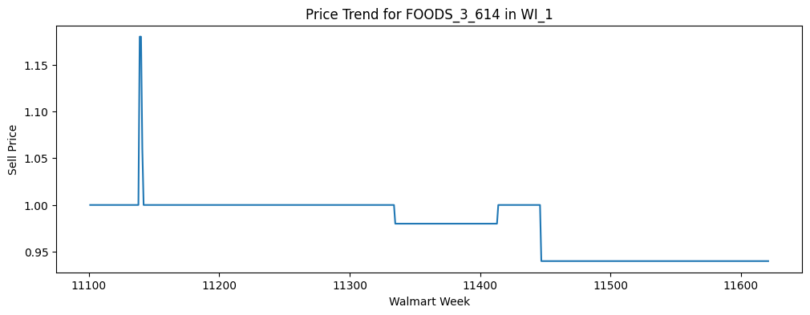

```python
sample_item = prices['item_id'].sample(1).iloc[0]
sample_store = prices['store_id'].sample(1).iloc[0]

subset = prices[(prices['item_id'] == sample_item) & (prices['store_id'] == sample_store)]

plt.figure(figsize=(12,4))
plt.plot(subset['wm_yr_wk'], subset['sell_price'])
plt.title(f"Price Trend for {sample_item} in {sample_store}")
plt.xlabel("Walmart Week")
plt.ylabel("Sell Price")
```

## Step 10: Convert Sales Table to Long Format

The original sales table has one column per day (`d_1` to `d_1913`). We melt it to long format to prepare for merging and time-series forecasting.

```python
sales_long = pd.melt(
    sales,
    id_vars=['id', 'item_id', 'dept_id', 'cat_id', 'store_id', 'state_id'],
    var_name='d',
    value_name='sales'
)
sales_long = sales_long.merge(calendar[['d', 'date']], how='left', on='d')
sales_long['date'] = pd.to_datetime(sales_long['date'])
sales_long.head()
```

|  | id | item_id | dept_id | cat_id | store_id | state_id | d | sales | date |
| --- | --- | --- | --- | --- | --- | --- | --- | --- | --- |
| 0 | HOBBIES_1_001_CA_1_validation | HOBBIES_1_001 | HOBBIES_1 | HOBBIES | CA_1 | CA | d_1 | 0 | 2011-01-29 |
| 1 | HOBBIES_1_002_CA_1_validation | HOBBIES_1_002 | HOBBIES_1 | HOBBIES | CA_1 | CA | d_1 | 0 | 2011-01-29 |
| 2 | HOBBIES_1_003_CA_1_validation | HOBBIES_1_003 | HOBBIES_1 | HOBBIES | CA_1 | CA | d_1 | 0 | 2011-01-29 |
| 3 | HOBBIES_1_004_CA_1_validation | HOBBIES_1_004 | HOBBIES_1 | HOBBIES | CA_1 | CA | d_1 | 0 | 2011-01-29 |
| 4 | HOBBIES_1_005_CA_1_validation | HOBBIES_1_005 | HOBBIES_1 | HOBBIES | CA_1 | CA | d_1 | 0 | 2011-01-29 |

### Extended EDA: Understanding Time, Target Distribution & Sales Dynamics

To further support our downstream feature engineering and modeling efforts, we perform a few additional analyses:

- Extract weekday names from the `calendar` data to explore seasonality patterns.
- Examine the distribution of our target variable `sales` to understand its skew.
- Visualize a log-transformed histogram to better interpret the long tail of sales.
- Plot total daily sales across all Walmart stores/items to observe global trends and anomalies (e.g., holidays).

```python
# 1. Add weekday name for later seasonality features
calendar['weekday'] = calendar['date'].dt.day_name()
calendar[['date', 'weekday']].head()
```

|  | date | weekday |
| --- | --- | --- |
| 0 | 2011-01-29 | Saturday |
| 1 | 2011-01-30 | Sunday |
| 2 | 2011-01-31 | Monday |
| 3 | 2011-02-01 | Tuesday |
| 4 | 2011-02-02 | Wednesday |

```python
# 2. Basic descriptive stats on the target
sales_long['sales'].describe()
```

```
count    5.832737e+07
mean     1.126322e+00
std      3.873108e+00
min      0.000000e+00
25%      0.000000e+00
50%      0.000000e+00
75%      1.000000e+00
max      7.630000e+02
Name: sales, dtype: float64
```

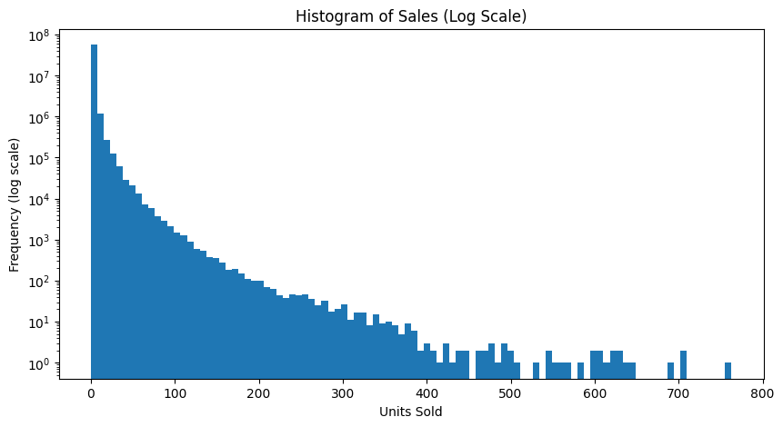

```python
# 3. Histogram of sales values (log scale for better tail visualization)
plt.figure(figsize=(10, 5))
sales_long['sales'].plot.hist(bins=100, log=True)
plt.title("Histogram of Sales (Log Scale)")
plt.xlabel("Units Sold")
plt.ylabel("Frequency (log scale)")
plt.show()
```

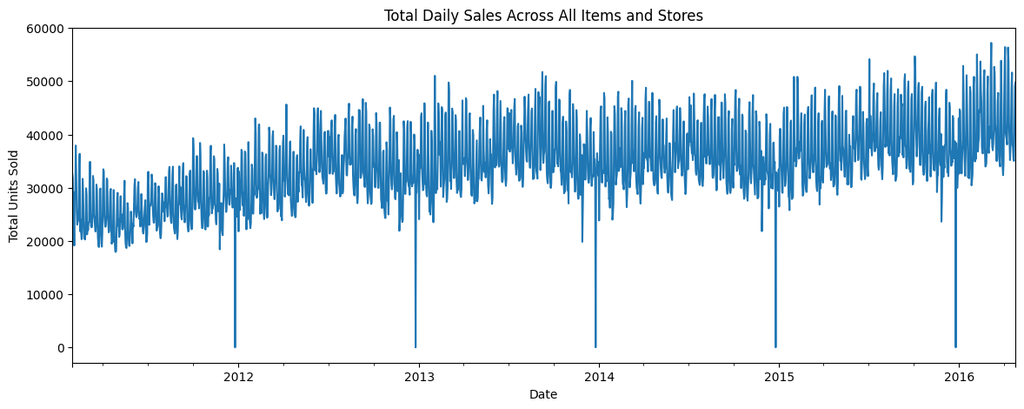

```python
# 4. Total daily sales over time (to see spikes/dips)
plt.figure(figsize=(14, 5))
sales_long.groupby('date')['sales'].sum().plot()
plt.title("Total Daily Sales Across All Items and Stores")
plt.xlabel("Date")
plt.ylabel("Total Units Sold")
plt.show()
```

**Author:** Anjali Rai

**Project:** Smart Inventory Forecasting & Anomaly Detection (Walmart M5)

**Last Updated:** April 2025

**Tools Used:** Pandas, NumPy, Matplotlib, Seaborn

**Target Roles:** Data Scientist, Machine Learning Engineer